# Effect of Text-Based Nudges on Behavior

Preview

vge00

2022-07-01

次に、wave 2 target dataを用いて、 我々は第1回調査以降の行動に対するナッジ・メッセージの効果を推定する。 第1回から第2回にかけて若干名が脱落しているので、我々は改めてバランステストを行い、 ２つのサブサンプルの両方で、 個人の観察可能な特徴はトリートメント間でバランスされていることを確認した（補論Bを見よ）。 そこで、ここでも本稿にはt検定の結果を掲載して、回帰分析の結果は補論Cに掲載する。 また、検定力80%・有意水準5%を保つために必要な効果の規模を計算したところ、 2019年度にクーポン券が自動で送付される男性のサブサンプルを用いる場合、少なくとも 7.2 %ポイントの差が必要である。 2019年度ではクーポン券を受け取るために手続きが必要な男性のサブサンプルを用いる場合、少なくとも 5.3 %ポイントの差が必要である。

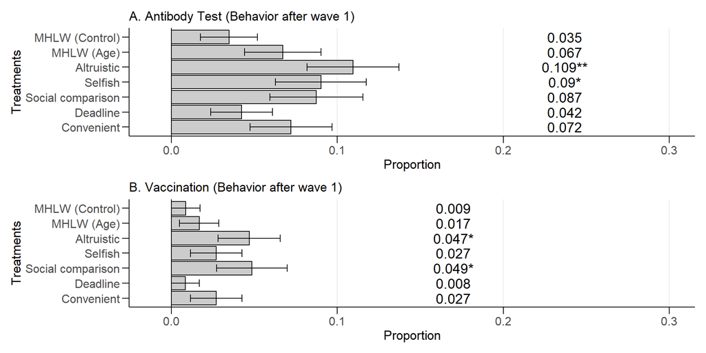

Figure 1: Effect of Text-Based Nudges on Behavior among Men for whom Coupons are Automatically Distributed in FY 2019 (N = 805). Data source: wave 2 selection data. Note: Numbers in the figure indicate the proportion of each group. Error bars indicate standard error of the mean. Asterisks are p-values for t-tests of the difference in means from the MHLW message group: * p < 0.1, ** p < 0.05, *** p < 0.01.

まず、2019年度にクーポン券が自動で送付される男性のサブサンプルを用いて、 我々は各介入群の抗体検査の受検率（パネルA）とワクチン接種率（パネルB）を 図1に示した[^1]。 その結果、意向のケースと同様に、厚労省メッセージに比べて、 利他強調メッセージが実際の抗体検査の受検率を高めることが分かった。 厚労省メッセージの受検率が約3.5%だったのに対して、 利他強調メッセージのそれは約10.9%だった。 したがって、利他強調メッセージの効果サイズは約7.4%ポイントであり、 これは統計的に5%水準で有意である。 この効果サイズは、上で計算した7.2%ポイントという基準よりも少しばかり大きい。 さらに、この利他強調メッセージは抗体検査受検率だけでなくワクチン接種率をも高める効果を持つことが示された。 この群の接種率は約4.7%であり、厚労省メッセージ（0.9%）に比べて3.8%ポイント高く、 これは10%水準で統計的に有意であった。

また、利己強調メッセージは抗体検査の受検率を高めている可能性が示唆された。 この群の抗体検査の受検率は約9%であり、 厚労省メッセージ（3.5%）に比べて5.5%ポイント高く、 これは統計的に10%水準で有意である。 さらに、社会比較メッセージはワクチン接種率を高めている可能性も示唆された。 この群のワクチン接種率は約4.9%であり、 厚労省メッセージ（0.9%）よりも4%ポイント高い。 これは統計的に10%水準で有意である。

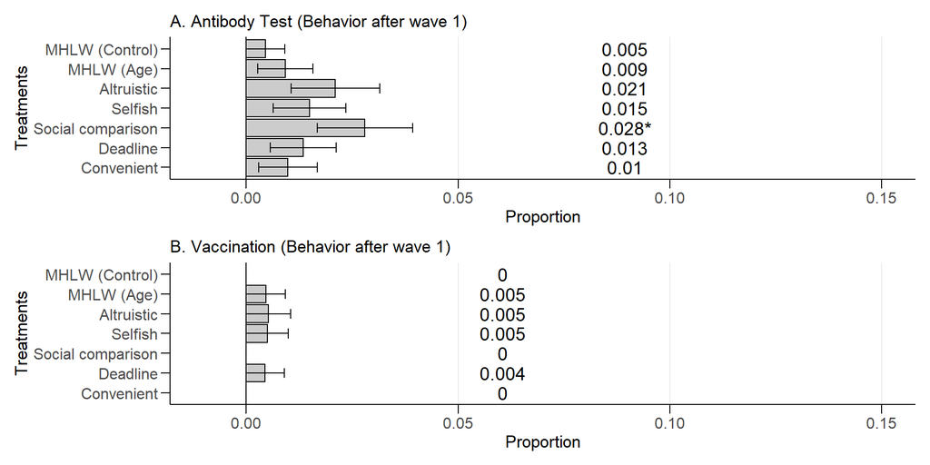

次に、2019年度にクーポン券を得るためにコストのかかる手続きが必要な男性のサブサンプルを用いて、 我々は各介入群の抗体検査の受検率（パネルA）とワクチン接種率（パネルB）を 図2に示した。 その結果、厚労省メッセージと比較して、 社会比較メッセージは抗体検査の受検率を高めているが、 ワクチン接種率を高めていない。 厚労省メッセージを読んだ人の0.5%が抗体検査を受検しているが、 誰もワクチン接種をしていない。 同様に、社会比較メッセージを読んだ人の2.8%が抗体検査を受検しているが、 誰もワクチン接種をしていない。 したがって、厚労省メッセージと比較して、 社会比較メッセージは抗体検査の受検率を約2.3%ポイント引き上げていて、 これは統計的に10%水準で有意である。 しかしながら、ワクチン接種率に対する効果はゼロである。

Table 1: Linear Probability Model of Behaviors

Antibody Test

Vaccination

MHLW (Age)

0.003

0.004

(0.008)

(0.005)

Altruistic

0.016

0.005

(0.011)

(0.005)

Selfish

0.007

0.005

(0.010)

(0.005)

Social comparison

0.022*

0.000

(0.013)

(0.001)

Deadline

0.009

0.005

(0.009)

(0.005)

Convenient

0.007

0.000

(0.009)

(0.001)

Coupon

0.019

0.003

(0.020)

(0.011)

Coupon×Age expression

0.026

0.002

(0.030)

(0.015)

Coupon×Altruistic

0.057*

0.032

(0.034)

(0.021)

Coupon×Selfish

0.054

0.013

(0.033)

(0.018)

Coupon×Social comparison

0.034

0.039*

(0.035)

(0.023)

Coupon×Valid date

－0.003

－0.006

(0.026)

(0.013)

Coupon×Low-cost

0.031

0.018

(0.031)

(0.018)

Num.Obs.

2272

2272

R2

0.080

0.040

R2 Adj.

0.069

0.028

Covariates

X

X

* p < 0.1, ** p < 0.05, *** p < 0.01

Table 2: Effects of Text-Based Nudges on Behaviors Using Linear Probability Model Estimates

| How to get coupons | Text-based nudges | Antibody Test estimate | Antibody Test std.error | Antibody Test p.value | Vaccination estimate | Vaccination std.error | Vaccination p.value |
| --- | --- | --- | --- | --- | --- | --- | --- |
| Costly procedure | MHLW (Age) | 0.003 | 0.008 | 0.755 | 0.004 | 0.005 | 0.436 |
|  | Altruistic | 0.016 | 0.011 | 0.159 | 0.005 | 0.005 | 0.381 |
|  | Selfish | 0.007 | 0.010 | 0.501 | 0.005 | 0.005 | 0.301 |
|  | Social comparison | 0.022 | 0.013 | 0.082 | 0.000 | 0.001 | 0.920 |
|  | Deadline | 0.009 | 0.009 | 0.346 | 0.005 | 0.005 | 0.318 |
|  | Convenient | 0.007 | 0.009 | 0.430 | 0.000 | 0.001 | 0.876 |
| Automatic receiving | MHLW (Age) | 0.029 | 0.028 | 0.307 | 0.006 | 0.015 | 0.702 |
|  | Altruistic | 0.073 | 0.032 | 0.023 | 0.037 | 0.020 | 0.071 |
|  | Selfish | 0.061 | 0.032 | 0.055 | 0.018 | 0.017 | 0.292 |
|  | Social comparison | 0.056 | 0.032 | 0.084 | 0.040 | 0.023 | 0.084 |
|  | Deadline | 0.005 | 0.025 | 0.833 | －0.002 | 0.012 | 0.897 |
|  | Convenient | 0.038 | 0.029 | 0.202 | 0.018 | 0.018 | 0.311 |

Table 3: Effects of Text-Based Nudges on Behaviors Using Linear Probability Model Estimates (Baseline: Altruistic Message)

| How to get coupons | Text-based nudges | Antibody Test estimate | Antibody Test std.error | Antibody Test p.value | Vaccination estimate | Vaccination std.error | Vaccination p.value |
| --- | --- | --- | --- | --- | --- | --- | --- |
| Costly procedure | MHLW (Age) | －0.013 | 0.012 | 0.287 | －0.001 | 0.007 | 0.898 |
|  | Selfish | －0.009 | 0.013 | 0.501 | 0.001 | 0.008 | 0.927 |
|  | Social comparison | 0.006 | 0.015 | 0.693 | －0.005 | 0.006 | 0.405 |
|  | Deadline | －0.007 | 0.013 | 0.569 | 0.000 | 0.007 | 0.999 |
|  | Convenient | －0.009 | 0.012 | 0.476 | －0.005 | 0.005 | 0.369 |
| Automatic receiving | MHLW (Age) | －0.044 | 0.036 | 0.218 | －0.031 | 0.022 | 0.158 |
|  | Selfish | －0.012 | 0.038 | 0.749 | －0.018 | 0.024 | 0.438 |
|  | Social comparison | －0.017 | 0.039 | 0.662 | 0.003 | 0.028 | 0.923 |
|  | Deadline | －0.068 | 0.033 | 0.039 | －0.038 | 0.020 | 0.058 |
|  | Convenient | －0.035 | 0.036 | 0.330 | －0.019 | 0.024 | 0.429 |

Table 4: Movement of Antibody Test Takers

| Text-based nudge | w/ receiving coupon automatically Antibody test | w/ receiving coupon automatically Negative test result | w/ receiving coupon automatically Vaccination | w/o receiving coupon automatically Antibody test | w/o receiving coupon automatically Negative test result | w/o receiving coupon automatically Vaccination |
| --- | --- | --- | --- | --- | --- | --- |
| MHLW (Control) | 4 | 1 | 1 | 1 | 0 | 0 |
| MHLW (Age) | 8 | 2 | 2 | 2 | 2 | 1 |
| Altruistic | 14 | 7 | 6 | 4 | 1 | 1 |
| Selfish | 10 | 3 | 3 | 3 | 1 | 1 |
| Social comparison | 9 | 5 | 5 | 6 | 1 | 0 |
| Deadline | 5 | 1 | 1 | 3 | 1 | 1 |
| Convenient | 8 | 5 | 3 | 2 | 0 | 0 |
| Fisher’s exact test (p-value) |  | 0.53 | 0.67 |  | 0.47 | 1.00 |

Note: Limiting our sample to antibody test takers, we tested the null hypothesis that the number of negative antibody tests does not differ between intervention groups with Fisher’s exact test. Also, restricting the sample to negative individuals, we tested the null hypothesis that the number of vaccinations would not differ between intervention groups with a Fisher’s exact test.

クーポン券が自動的に送付されるかどうかに関わらず、 すべての群において、ワクチン接種率は抗体検査の受験率より低い。 これは陰性であるにも関わらずワクチンを接種していない人が多いからではなく、 もともと抗体を持っていたためにワクチンを接種するべき人が少ない という外生的な要因によるものであると考えられる。 この点を明らかにするために、 我々は抗体検査の受検者数・抗体検査が陰性であった人の数・ワクチンを接種した人数を 介入群ごとに計算し、表4に示した。

表4より、 クーポン券が自動的に送付されかどうかや介入群に関わらず 抗体検査の結果が陰性である人のほとんどがワクチンを接種している[^2]。 2019年度にクーポン券を自動的に受け取った男性に限定すると、 利他強調メッセージ・低コストメッセージを除くすべての群で 陰性者はワクチンを接種している。 また、利他強調メッセージ・低コストメッセージ群においても ワクチンを接種していない陰性者は少数である。 同様に、2019年度にクーポン券を受け取るためにはコストのかかる手続きが必要な男性に限定すると、 年齢表現メッセージ・社会比較メッセージを除くすべての群で 陰性者はワクチンを接種している。

さらに、表4より、 抗体検査の陰性件数が介入群間でバラツキがあることが分かる。 2019年度にクーポン券を自動的に受け取った男性に限定したとき、 厚労省メッセージの抗体検査の陰性比率は25%($=1/4$)である。 これに対して、ワクチン接種率に対して効果のある 利他強調メッセージ・社会比較メッセージの抗体検査の陰性比率は それぞれ50%（$=7/14$）・55%（$=5/9$）である。 逆に、抗体検査受検率のみに効果のある利己強調メッセージの抗体検査の陰性比率は 30%($=3/10$)であり、 厚労省メッセージのそれと近い値を取る。 2019年度にクーポン券を受け取るためにはコストのかかる手続きが必要な男性に限定するとき、 抗体検査受検率のみに効果のある社会比較メッセージの抗体検査の陰性比率は16%（$=1/6$）である。 したがって、 ワクチン接種率が高い介入群は陰性比率が高く、 それがワクチン接種率に対する効果に影響を与えたといえる。

ただし、抗体検査の陰性比率の介入群間のばらつきは統計的な誤差による可能性が高い。 我々はクーポン券を自動的に送付される対象かどうかでサンプルを分割し、 抗体検査の陰性件数が介入群間で異ならないという帰無仮説を フィッシャーの正確検定で検証した。 その結果、二つのサブサンプルでこの帰無仮説を棄却できない。 よって、我々のデータの抗体検査の陰性比率は介入群間で異なっているが、 母集団のそれは介入群間で異ならないかもしれない[^3]。